# accumbens_and_learning

Ben Smith

2022-12-19

We’ve noticed an accumbens signal that has a particularly pronounced CS-FS difference among late trials.

That led us to ask: is it correlated with reaction time; specifically,

1. is accumbens BOLD CS-FS contrast at tone+5 s (which reacts negatively) negatively related to longer reaction times in subsequent trials, and
2. is accumbens bold CS-FS contrast at tone+9 (which reacts positively) positively related to longer reaction times in subsequent trials?

We are really mostly interested in FS so at the trial level we’d do

1. is accumbens BOLD FS contrast at tone+5 s (which reacts positively) positively related to longer reaction times in subsequent trials, and
2. is accumbens bold FS contrast at tone+9 (which reacts negatively) negatively related to longer reaction times in subsequent trials?

```r
library(tidyverse)
Sys.setenv(R_CONFIG_ACTIVE = Sys.info()["nodename"])
print(Sys.info()["nodename"])
```

```
##                        nodename
## "Benjamins-MacBook-Pro-2.local"
```

```r
dropbbox_dir <- config::get("dev_analysis_data_dir")
```

```r
time_points <- readr::read_csv(paste0(dropbbox_dir,"/SST_roi_by_time_point.csv"))
```

```
## ──────────────────────────────────────────────────────── Delimiter: "," chr
## (3): subid, go_no_go_condition_label, condition dbl (15): ...1, tr, offset,
## CueFollowing(CS>FS)striatal_cluster_combined, ha...
```

So how do we design this experiment; what are we correlating over, exactly? Some designs are:

1. Across subject, so:
1. apply the script I have created on late trials to get average measurements every 10 s–maybe the last half or third of the task, not just the last few, but do this at a per subject level
2. take the MAXIMUM accumbens activity at the 1-9 s range across trials for each subject (to get the peak), and the MINIMUM accumbens activity at the 4-12 s range (to get the trough)
3. correlate across subject average reaction times, or post-pre change in reaction times
2. Within subject, so:
1. get peak and trough accumbens signal for each FS trial in the last third of the task. Perhaps use the difference between the peak and trough as your measure. Though we’re really now kind of getting a crude HRF…the advantage of this measure is we aren’t bound to a particular shape of it, which is probably useful.
2. get (i) reaction time and (ii) post-pre difference for subsequent go trial
3. correlate the difference of peak and trough gathered in (a) with the two measures in (b). Summarize in two ways: i. get average correlations within-subject, then average across subjects as a crude multi-level model to test across subject ii. apply a true multi-level model

We’ll want to re-use existing pre-post data.

So–this will yield quite different data to the data we used previously!

```r
roi_cols <- colnames(time_points)[grepl("harvardoxford",colnames(time_points))]
time_points$tr_roi_mean <- rowMeans(time_points[,roi_cols])
time_points<-
  time_points %>% group_by(subid,wave) %>%
  mutate(run_mean_across_rois = mean(tr_roi_mean, na.rm = TRUE))

#now mean-center the ROIs
time_points_c<-time_points
for (roi_col in roi_cols){
  time_points_c[,roi_col]<-time_points_c[,roi_col]-time_points_c$run_mean_across_rois
}

#roi_cols <- colnames(time_points_c)[grepl("harvardoxford",colnames(time_points_c))]
#roi_cols_all <- colnames(time_points_c)#[grepl("((?<=harvardoxford-.{0,3}cortical_prob_)(.*))|(CueFollowing\\(CS\\>FS\\).*)",colnames(time_points_c),perl=TRUE)]
roi_detect_pattern<-"((?<=harvardoxford-.{0,3}cortical_prob_)(.*))|(CueFollowing\\(CS\\>FS\\).*)"

roi_cols_vec <- colnames(time_points_c) %>% stringr::str_detect(pattern = roi_detect_pattern)
new_roi_cols <- colnames(time_points_c) %>% stringr::str_extract_all(pattern = roi_detect_pattern) %>% unlist
unique(new_roi_cols)
```

```
## [1] "CueFollowing(CS>FS)striatal_cluster_combined"
## [2] "Frontal Orbital Cortex"
## [3] "Cingulate Gyrus, anterior division"
## [4] "Left Caudate"
## [5] "Right Accumbens"
## [6] "Right Putamen"
## [7] "Left Putamen"
## [8] "Right Caudate"
## [9] "Left Accumbens"
```

```r
colnames(time_points_c)[roi_cols_vec] <- new_roi_cols
```

We need to group by subject, wave, and trial, select just the FailedStop trials, and just the high trial numbers, then get the min and max accumbens activity. We could even do a long transform across the ROIs, then also group by ROI and get the min and max for ROIs

So let’s first long transform the ROIs

```r
tpc_long<-time_points_c %>% pivot_longer(cols=all_of(new_roi_cols),names_to="ROI",values_to="value")
```

Now do the grouping and summarizing.

```r
FS_summary_data <- tpc_long %>%
  filter(condition=="FailedStop") %>%
  group_by(subid,wave,trial_n,ROI) %>%
  summarise(
    peak=max(value[offset>=2.0 & offset <=8.0],na.rm = TRUE),
    trough = min(value[offset>=0.0 & offset <=5.0],na.rm = TRUE),
    peak_time = offset[offset>=2.0 & offset <=8.0][value[offset>=2.0 & offset <=8.0]==max(value[offset>=2.0 & offset <=8.0],na.rm = TRUE)],
    trough_time = offset[offset>=0.0 & offset <=5.0][value[offset>=0.0 & offset <=5.0]==min(value[offset>=0.0 & offset <=5.0],na.rm = TRUE)]
  )
```

[output not shown]

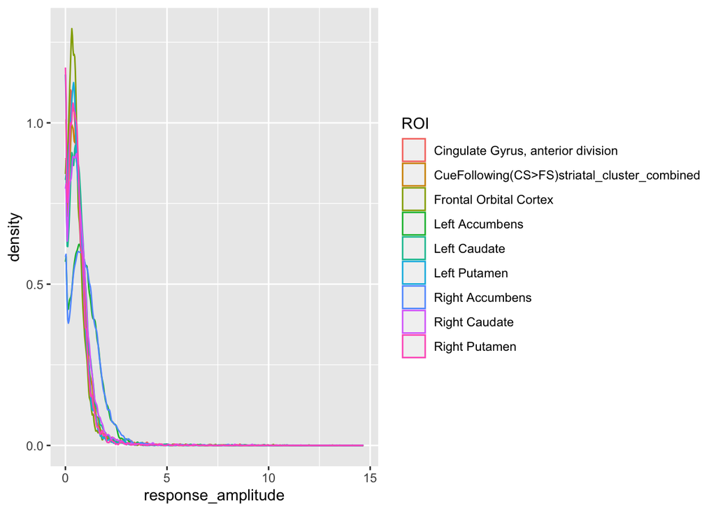

```r
FS_summary_data$response_amplitude <-FS_summary_data$peak-FS_summary_data$trough

ggplot(FS_summary_data,aes(response_amplitude,group=ROI,color=ROI))+geom_density(adjust=0.5)
```

OK. So now, let’s try to merge in that with post-pre RTs. Where do we get those from?

## get the SST Post-pre data

```r
source(paste0(config::get("ben_dev_data_analysis"),"SST_processing.R"))

dropbox_file_dir = config::get("dev_analysis_data_dir")
sst_all_data_filepath <- paste0(dropbox_file_dir,"sst_behavioral_data_all.csv")

sst_all_data_raw <- readr::read_csv(sst_all_data_filepath)
sst_all_data<-clean_sst_data(sst_all_data_raw)
sst_all_data <- get_expected_tone_time(sst_all_data)

sst_all_data<-calculate_response_latency(sst_all_data)
sst_all_data<-calculate_rpe(sst_all_data)

#
# sst_all_data %>% select(
#   subid, waveid, runid, reaction_time_clean, SSD_recorded,condition, last_tone_delay, trials_since_last_SSD,last_correct_go)# %>%
#   #View()
```

```r
readr::write_csv(sst_all_data,file=paste0(dropbox_file_dir,"sst_behavioral_data_all_with_analysis.csv"))
```

```r
post_pre_rt_data <- sst_all_data%>%
  filter(condition!="Cue") #%>%
  #select(trial_n,reaction_time,subid,waveid,runid,condition,post_pre_rt_change)
```

## Prepare neural data

```r
FS_summary_data$ROI_delateralized <-  FS_summary_data$ROI %>% str_replace_all("(Left|Right)\\s","")


FS_summary_data_delat <- FS_summary_data %>%
  #filter(ROI %in% c("Left Accumbens","Right Accumbens")) %>%
  group_by(subid,wave,trial_n, ROI_delateralized) %>%
  summarize(peak=mean(peak),
            trough=mean(trough),
            peak_time=mean(peak_time),
            trough_time=mean(trough_time),
            response_amplitude=mean(response_amplitude))
```

## Merge the datasets

```r
FS_summary_data_delat_pp <- merge(FS_summary_data_delat,post_pre_rt_data,by.x = c("subid","wave","trial_n"),by.y=c("subid","waveid","trial_n"),all.x = TRUE)

FS_summary_data_delat_pp$trial_n_c<-128-FS_summary_data_delat_pp$trial_n

FS_summary_data_accumbens <- FS_summary_data_delat_pp %>% filter(ROI_delateralized=="Accumbens") %>% select(-ROI_delateralized)



FS_neural_behav_data_not_na<-FS_summary_data_accumbens[
  rowSums(is.na(FS_summary_data_accumbens[,c("response_amplitude","post_pre_rt_change")]))==0 & #no NA values in correlation and
    is.finite(FS_summary_data_accumbens$response_amplitude) & is.finite(FS_summary_data_accumbens$post_pre_rt_change) #no infinite values
    ,]
```

#now test. let’s trun across all at first….

```r
cor.test(FS_neural_behav_data_not_na$response_amplitude,FS_neural_behav_data_not_na$post_pre_rt_change)
```

```
##
##  Pearson's product-moment correlation
##
## data:  FS_neural_behav_data_not_na$response_amplitude and FS_neural_behav_data_not_na$post_pre_rt_change
## t = 1.319, df = 4860, p-value = 0.1872
## alternative hypothesis: true correlation is not equal to 0
## 95 percent confidence interval:
##  -0.009198022  0.047001794
## sample estimates:
##        cor
## 0.01891683
```

```r
cor.test(FS_neural_behav_data_not_na$peak,FS_neural_behav_data_not_na$post_pre_rt_change)
```

```
##
##  Pearson's product-moment correlation
##
## data:  FS_neural_behav_data_not_na$peak and FS_neural_behav_data_not_na$post_pre_rt_change
## t = 0.97753, df = 4860, p-value = 0.3284
## alternative hypothesis: true correlation is not equal to 0
## 95 percent confidence interval:
##  -0.01409481  0.04211407
## sample estimates:
##        cor
## 0.01402071
```

```r
cor.test(FS_neural_behav_data_not_na$peak,FS_neural_behav_data_not_na$reaction_time)
```

```
##
##  Pearson's product-moment correlation
##
## data:  FS_neural_behav_data_not_na$peak and FS_neural_behav_data_not_na$reaction_time
## t = 0.37175, df = 4860, p-value = 0.7101
## alternative hypothesis: true correlation is not equal to 0
## 95 percent confidence interval:
##  -0.02278097  0.03343735
## sample estimates:
##         cor
## 0.005332403
```

```r
cor_val<-cor.test(FS_neural_behav_data_not_na$trough,FS_neural_behav_data_not_na$post_pre_rt_change)
print(cor_val)
```

```
##
##  Pearson's product-moment correlation
##
## data:  FS_neural_behav_data_not_na$trough and FS_neural_behav_data_not_na$post_pre_rt_change
## t = -0.71513, df = 4860, p-value = 0.4746
## alternative hypothesis: true correlation is not equal to 0
## 95 percent confidence interval:
##  -0.03835644  0.01785757
## sample estimates:
##         cor
## -0.01025754
```

```r
FS_by_subj_raw <- FS_neural_behav_data_not_na %>% group_by(subid) %>%
  mutate(trial_count=n())
FS_by_subj <- FS_by_subj_raw %>% filter(trial_count >2) %>%
  summarize(peak_cor_est = cor.test(peak,post_pre_rt_change)$estimate,
            amplitude_cor_est = cor.test(response_amplitude,post_pre_rt_change)$estimate,
            mean_post_pre_rt_change=mean(post_pre_rt_change),
            mean_post_current_rt_change=mean(post_current_rt_change),
            mean_peak=mean(peak),
            mean_trough=mean(trough),
            mean_amplitude=mean(response_amplitude),
            trial_count=n()
            )

t.test(FS_by_subj$peak_cor_est)
```

```
##
##  One Sample t-test
##
## data:  FS_by_subj$peak_cor_est
## t = 1.1315, df = 243, p-value = 0.259
## alternative hypothesis: true mean is not equal to 0
## 95 percent confidence interval:
##  -0.01479183  0.05472405
## sample estimates:
##  mean of x
## 0.01996611
```

```r
t.test(FS_by_subj$amplitude_cor_est)
```

```
##
##  One Sample t-test
##
## data:  FS_by_subj$amplitude_cor_est
## t = -1.0808, df = 243, p-value = 0.2808
## alternative hypothesis: true mean is not equal to 0
## 95 percent confidence interval:
##  -0.04954886  0.01443829
## sample estimates:
##   mean of x
## -0.01755529
```

Would strengthen the data

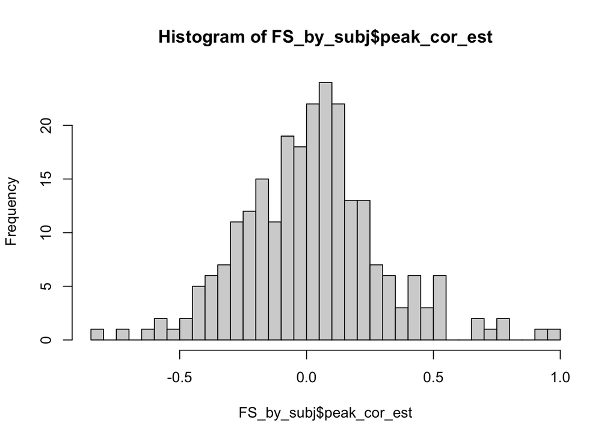

```r
hist(FS_by_subj$peak_cor_est,breaks=40)
```

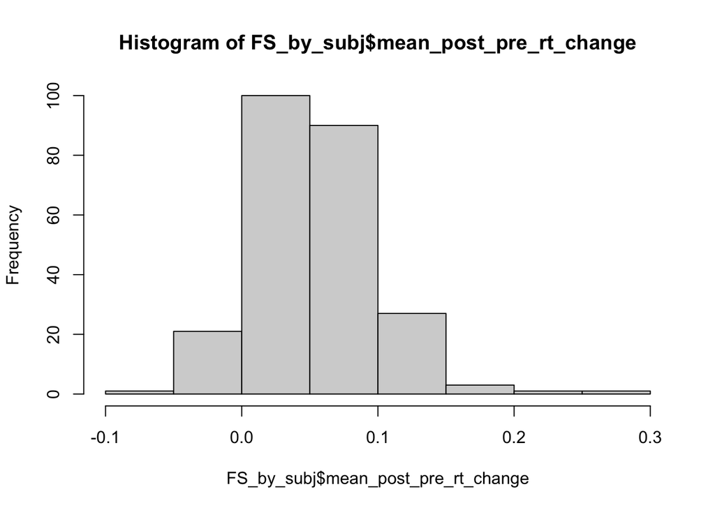

```r
hist(FS_by_subj$mean_post_pre_rt_change)
```

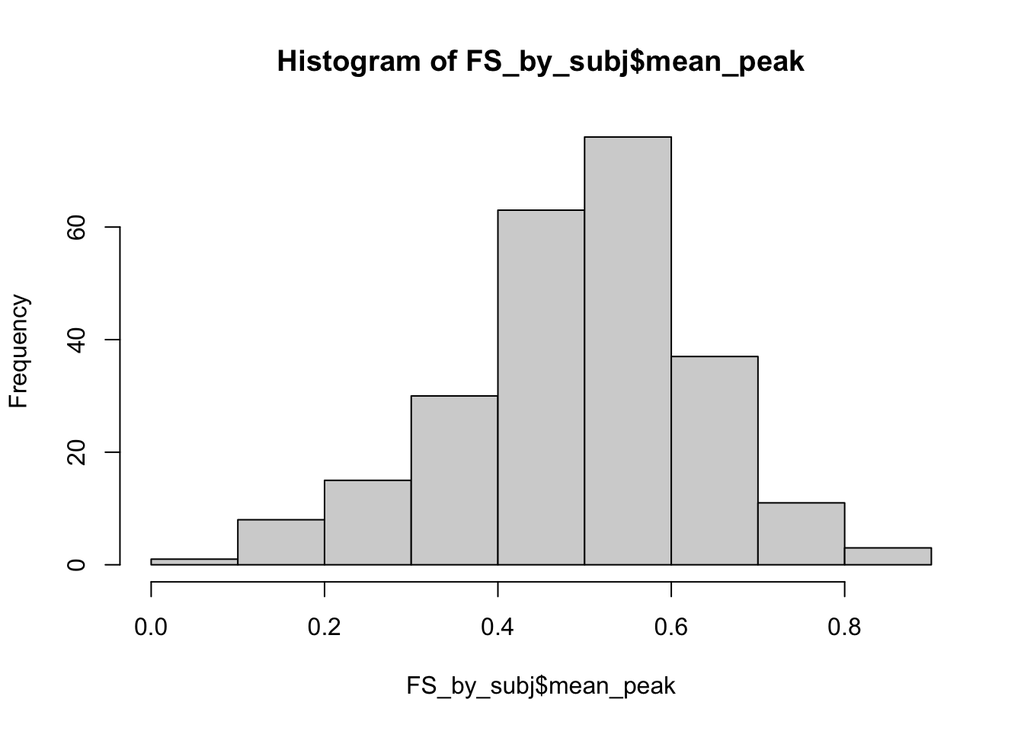

```r
hist(FS_by_subj$mean_peak)
```

```r
cor.test(FS_by_subj$mean_post_pre_rt_change,FS_by_subj$mean_trough)
```

```
##
##  Pearson's product-moment correlation
##
## data:  FS_by_subj$mean_post_pre_rt_change and FS_by_subj$mean_trough
## t = -2.933, df = 242, p-value = 0.003679
## alternative hypothesis: true correlation is not equal to 0
## 95 percent confidence interval:
##  -0.30379282 -0.06111177
## sample estimates:
##        cor
## -0.1852756
```

```r
cor.test(FS_by_subj$mean_post_pre_rt_change,FS_by_subj$mean_peak)
```

```
##
##  Pearson's product-moment correlation
##
## data:  FS_by_subj$mean_post_pre_rt_change and FS_by_subj$mean_peak
## t = 0.44743, df = 242, p-value = 0.655
## alternative hypothesis: true correlation is not equal to 0
## 95 percent confidence interval:
##  -0.09718686  0.15378045
## sample estimates:
##        cor
## 0.02874986
```

```r
cor.test(FS_by_subj$mean_post_pre_rt_change,FS_by_subj$mean_amplitude)
```

```
##
##  Pearson's product-moment correlation
##
## data:  FS_by_subj$mean_post_pre_rt_change and FS_by_subj$mean_amplitude
## t = 3.1388, df = 242, p-value = 0.001907
## alternative hypothesis: true correlation is not equal to 0
## 95 percent confidence interval:
##  0.07403653 0.31553177
## sample estimates:
##       cor
## 0.1977834
```

```r
cor.test(FS_by_subj$mean_post_pre_rt_change,FS_by_subj$mean_peak,method="spearman")
```

```
##
##  Spearman's rank correlation rho
##
## data:  FS_by_subj$mean_post_pre_rt_change and FS_by_subj$mean_peak
## S = 2279858, p-value = 0.364
## alternative hypothesis: true rho is not equal to 0
## sample estimates:
##        rho
## 0.05833406
```

Not significant within subjects, either. OK. We can do a multi-level model but I don’t think we’re quite capable of pulling this out.

If you take away the accumbens selection, you do get some significant results, but these are taking false precision…

## Between subjects

```r
FS_neural_behav_data_not_na<-FS_summary_data_delat_pp[
  rowSums(is.na(FS_summary_data_delat_pp[,c("response_amplitude","post_pre_rt_change")]))==0 & #no NA values in correlation and
    is.finite(FS_summary_data_delat_pp$response_amplitude) & is.finite(FS_summary_data_delat_pp$post_pre_rt_change) #no infinite values
    ,]
```

```r
full_run_data <- sst_all_data %>% group_by(subid,waveid,runid) %>%
  summarize(mean_SSD_all_stop_trials=mean(SSD_recorded[SSD_recorded!=0]))
FS_by_subj_raw <- FS_neural_behav_data_not_na %>% group_by(ROI_delateralized, subid) %>%
  mutate(trial_count=n())
FS_by_subj <- FS_by_subj_raw %>% group_by(ROI_delateralized, subid,trial_count) %>% filter(trial_count >2) %>%
  summarize(peak_cor_est = cor.test(peak,post_pre_rt_change)$estimate,
            trough_cor_est = cor.test(trough,post_pre_rt_change)$estimate,
            amplitude_cor_est = cor.test(response_amplitude,post_pre_rt_change)$estimate,
            mean_post_pre_rt_change=mean(post_pre_rt_change),
            mean_post_current_rt_change=mean(post_current_rt_change),
            mean_post_rt=mean(next_reaction_time),
            mean_peak=mean(peak),
            mean_trough=mean(trough),
            mean_amplitude=mean(response_amplitude),
            mean_peak_offset=mean(peak_time),
            mean_trough_offset=mean(trough_time),

            )
FS_by_subj<-merge(FS_by_subj,
                  full_run_data %>% filter(runid==1 & waveid==1),
                  by='subid',how='left'
                  )

FS_neural_behav_data_not_na <- merge(
  FS_neural_behav_data_not_na,
  full_run_data %>% filter(runid==1 & waveid==1),
                  by='subid',how='left'
                  )
```

Per subject:

```r
roi_within_subj_list<-list()

for (roi_i in unique(FS_by_subj$ROI_delateralized)){
  # cat("\n")
  # cat(roi_i)
  # cat("\n")
  peak<-t.test(FS_by_subj %>% filter(ROI_delateralized==roi_i) %>% .$peak_cor_est)
  trough<-t.test(FS_by_subj %>% filter(ROI_delateralized==roi_i) %>% .$trough_cor_est)
  amplitude<-t.test(FS_by_subj %>% filter(ROI_delateralized==roi_i) %>% .$amplitude_cor_est)
  # print(peak)
  # print(trough)
  # print(amplitude)

  roi_within_subj_row<-data.frame("roi"=roi_i,"measure"="peak","t"=peak[[1]],"estimate"=peak$estimate, "pvalue"=peak$p.value)
  roi_within_subj_list<-append(roi_within_subj_list,list(roi_within_subj_row))
  roi_within_subj_row<-data.frame("roi"=roi_i,"measure"="trough","t"=trough[[1]],"estimate"=trough$estimate, "pvalue"=trough$p.value)
  roi_within_subj_list<-append(roi_within_subj_list,list(roi_within_subj_row))
  roi_within_subj_row<-data.frame("roi"=roi_i,"measure"="amplitude","t"=amplitude[[1]],"estimate"=amplitude$estimate, "pvalue"=amplitude$p.value)
  roi_within_subj_list<-append(roi_within_subj_list,list(roi_within_subj_row))
  # cat("---\n")
}
print("example:")
```

```
## [1] "example:"
```

```r
cat(roi_i)
```

```
## Putamen
```

```r
cat("\n")
```

```r
print(peak)
```

```
##
##  One Sample t-test
##
## data:  FS_by_subj %>% filter(ROI_delateralized == roi_i) %>% .$peak_cor_est
## t = 0.82871, df = 243, p-value = 0.4081
## alternative hypothesis: true mean is not equal to 0
## 95 percent confidence interval:
##  -0.01882248  0.04616263
## sample estimates:
##  mean of x
## 0.01367008
```

```r
  print(trough)
```

```
##
##  One Sample t-test
##
## data:  FS_by_subj %>% filter(ROI_delateralized == roi_i) %>% .$trough_cor_est
## t = 0.92329, df = 243, p-value = 0.3568
## alternative hypothesis: true mean is not equal to 0
## 95 percent confidence interval:
##  -0.01700741  0.04701817
## sample estimates:
##  mean of x
## 0.01500538
```

```r
  print(amplitude)
```

```
##
##  One Sample t-test
##
## data:  FS_by_subj %>% filter(ROI_delateralized == roi_i) %>% .$amplitude_cor_est
## t = -0.51288, df = 243, p-value = 0.6085
## alternative hypothesis: true mean is not equal to 0
## 95 percent confidence interval:
##  -0.04574924  0.02684703
## sample estimates:
##    mean of x
## -0.009451103
```

```r
  cat("---\n")
roi_within_subj_df <- do.call(rbind,roi_within_subj_list)

library(stats)
roi_within_subj_df$pvalue_fdr_adjust<-p.adjust(roi_within_subj_df$pvalue,method="fdr")
roi_within_subj_df <- roi_within_subj_df %>% mutate(signif=ifelse(pvalue_fdr_adjust<0.05,"*",""))

print("summary:")
```

```
## [1] "summary:"
```

```r
print(roi_within_subj_df)
```

```
##                                              roi   measure          t
## t                                      Accumbens      peak  1.1315037
## t1                                     Accumbens    trough  1.8208009
## t2                                     Accumbens amplitude -1.0808405
## t3                                       Caudate      peak  1.1099369
## t4                                       Caudate    trough  0.2031292
## t5                                       Caudate amplitude  0.1347149
## t6            Cingulate Gyrus, anterior division      peak  2.9574407
## t7            Cingulate Gyrus, anterior division    trough  0.9285864
## t8            Cingulate Gyrus, anterior division amplitude  1.5279054
## t9  CueFollowing(CS>FS)striatal_cluster_combined      peak  3.1763924
## t10 CueFollowing(CS>FS)striatal_cluster_combined    trough  2.8429682
## t11 CueFollowing(CS>FS)striatal_cluster_combined amplitude -0.2068598
## t12                       Frontal Orbital Cortex      peak  1.7957636
## t13                       Frontal Orbital Cortex    trough  2.0973915
## t14                       Frontal Orbital Cortex amplitude -0.2748220
## t15                                      Putamen      peak  0.8287119
## t16                                      Putamen    trough  0.9232941
## t17                                      Putamen amplitude -0.5128787
##         estimate      pvalue pvalue_fdr_adjust signif
## t    0.019966111 0.258958557        0.50551128
## t1   0.030045808 0.069866977        0.22132326
## t2  -0.017555285 0.280839598        0.50551128
## t3   0.018729829 0.268123373        0.50551128
## t4   0.003432493 0.839204037        0.88856898
## t5   0.002337363 0.892948800        0.89294880
## t6   0.051542577 0.003407885        0.02909802      *
## t7   0.015411410 0.354024949        0.53515471
## t8   0.027192715 0.127836622        0.32872274
## t9   0.054507866 0.001684178        0.02909802      *
## t10  0.048671354 0.004849669        0.02909802      *
## t11 -0.003536715 0.836292607        0.88856898
## t12  0.032757001 0.073774418        0.22132326
## t13  0.035216985 0.036992456        0.16646605
## t14 -0.004567052 0.783686530        0.88856898
## t15  0.013670077 0.408080690        0.56503480
## t16  0.015005384 0.356769806        0.53515471
## t17 -0.009451103 0.608502066        0.78235980
```

Look ## across subjects

```r
roi_inddiv_list<-list()
for (roi_i in unique(FS_by_subj$ROI_delateralized)){
  cat("\n")
  cat(roi_i)
  cat("\n")
  FS_by_subj_i <- FS_by_subj %>% filter(ROI_delateralized==roi_i)

  peak<-cor.test(FS_by_subj_i$mean_post_pre_rt_change,FS_by_subj_i$mean_peak)
  trough<-cor.test(FS_by_subj_i$mean_post_pre_rt_change,FS_by_subj_i$mean_trough)
  amplitude<-cor.test(FS_by_subj_i$mean_post_pre_rt_change,FS_by_subj_i$mean_amplitude)
  #roi_inddiv_row<-data.frame("roi"=character(0),"measure"=character(0),"value"=numeric(0))
  roi_inddiv_row<-data.frame("roi"=roi_i,"measure"="peak","value"=peak[[1]],"estimate"=peak$estimate,"pvalue"=peak$p.value)
  roi_inddiv_list<-append(roi_inddiv_list,list(roi_inddiv_row))
  roi_inddiv_row<-data.frame("roi"=roi_i,"measure"="trough","value"=trough[[1]],"estimate"=trough$estimate,"pvalue"=trough$p.value)
  roi_inddiv_list<-append(roi_inddiv_list,list(roi_inddiv_row))
  roi_inddiv_row<-data.frame("roi"=roi_i,"measure"="amplitude","value"=amplitude[[1]],"estimate"=amplitude$estimate,"pvalue"=amplitude$p.value)
  roi_inddiv_list<-append(roi_inddiv_list,list(roi_inddiv_row))
  # print(peak)
  # print(trough)
  # print(amplitude)
  # cat("---\n")
}
```

```
##
## Accumbens
##
## Caudate
##
## Cingulate Gyrus, anterior division
##
## CueFollowing(CS>FS)striatal_cluster_combined
##
## Frontal Orbital Cortex
##
## Putamen
```

```r
print("example of full analyses for last ROI")
```

```
## [1] "example of full analyses for last ROI"
```

```r
cat(roi_i)
```

```
## Putamen
```

```r
  cat("\n")
```

```r
print(peak)
```

```
##
##  Pearson's product-moment correlation
##
## data:  FS_by_subj_i$mean_post_pre_rt_change and FS_by_subj_i$mean_peak
## t = 1.8961, df = 242, p-value = 0.05913
## alternative hypothesis: true correlation is not equal to 0
## 95 percent confidence interval:
##  -0.004663799  0.242888029
## sample estimates:
##       cor
## 0.1209929
```

```r
print(trough)
```

```
##
##  Pearson's product-moment correlation
##
## data:  FS_by_subj_i$mean_post_pre_rt_change and FS_by_subj_i$mean_trough
## t = -2.6562, df = 242, p-value = 0.008429
## alternative hypothesis: true correlation is not equal to 0
## 95 percent confidence interval:
##  -0.28781185 -0.04364634
## sample estimates:
##        cor
## -0.1683096
```

```r
print(amplitude)
```

```
##
##  Pearson's product-moment correlation
##
## data:  FS_by_subj_i$mean_post_pre_rt_change and FS_by_subj_i$mean_amplitude
## t = 3.4241, df = 242, p-value = 0.0007244
## alternative hypothesis: true correlation is not equal to 0
## 95 percent confidence interval:
##  0.09185679 0.33159677
## sample estimates:
##       cor
## 0.2149628
```

```r
cat("---\n")
print("summary")
```

```
## [1] "summary"
```

```r
roi_inddiv_df <- do.call(rbind,roi_inddiv_list)

library(stats)
roi_inddiv_df$pvalue_fdr_adjust<-p.adjust(roi_inddiv_df$pvalue,method="fdr")
roi_inddiv_df <- roi_inddiv_df %>% mutate(signif=ifelse(pvalue_fdr_adjust<0.05,"*",""))

print(roi_inddiv_df)
```

```
##                                              roi   measure      value
## t                                      Accumbens      peak  0.4474279
## t1                                     Accumbens    trough -2.9329927
## t2                                     Accumbens amplitude  3.1387917
## t3                                       Caudate      peak  1.3392252
## t4                                       Caudate    trough -3.0108938
## t5                                       Caudate amplitude  3.5857260
## t6            Cingulate Gyrus, anterior division      peak  0.7533669
## t7            Cingulate Gyrus, anterior division    trough -3.2504299
## t8            Cingulate Gyrus, anterior division amplitude  3.4668576
## t9  CueFollowing(CS>FS)striatal_cluster_combined      peak  1.2953542
## t10 CueFollowing(CS>FS)striatal_cluster_combined    trough -2.7338054
## t11 CueFollowing(CS>FS)striatal_cluster_combined amplitude  3.2798081
## t12                       Frontal Orbital Cortex      peak  1.1107915
## t13                       Frontal Orbital Cortex    trough -2.5178377
## t14                       Frontal Orbital Cortex amplitude  2.9204031
## t15                                      Putamen      peak  1.8961378
## t16                                      Putamen    trough -2.6561753
## t17                                      Putamen amplitude  3.4240842
##        estimate       pvalue pvalue_fdr_adjust signif
## t    0.02874986 0.6549663664       0.654966366
## t1  -0.18527565 0.0036792868       0.007651782      *
## t2   0.19778337 0.0019070802       0.005721241      *
## t3   0.08577141 0.1817538435       0.233683513
## t4  -0.19002114 0.0028807570       0.007407661      *
## t5   0.22460967 0.0004065678       0.004346206      *
## t6   0.04837157 0.4519617475       0.478547733
## t7  -0.20452856 0.0013160372       0.004737734      *
## t8   0.21752181 0.0006229727       0.004346206      *
## t9   0.08298133 0.1964323848       0.235718862
## t10 -0.17308332 0.0067232499       0.012101850      *
## t11  0.20629880 0.0011916343       0.004737734      *
## t12  0.07122305 0.2677605099       0.301230574
## t13 -0.15977353 0.0124544041       0.018681606      *
## t14  0.18450749 0.0038258909       0.007651782      *
## t15  0.12099289 0.0591330073       0.081876472
## t16 -0.16830959 0.0084286299       0.013792303      *
## t17  0.21496282 0.0007243677       0.004346206      *
```

# between-subjects correlations post_current and rt

```r
roi_inddiv_list<-list()
#for (roi_i in unique(FS_by_subj$ROI_delateralized)){
roi_i<-"Putamen"
  cat("\n")
```

```r
  cat(roi_i)
```

```
## Putamen
```

```r
  cat("\n")
```

```r
  FS_by_subj_i <- FS_by_subj %>% filter(ROI_delateralized==roi_i)

  peak<-cor.test(FS_by_subj_i$mean_post_current_rt_change,FS_by_subj_i$mean_peak)
  trough<-cor.test(FS_by_subj_i$mean_post_current_rt_change,FS_by_subj_i$mean_trough)
  amplitude<-cor.test(FS_by_subj_i$mean_post_current_rt_change,FS_by_subj_i$mean_amplitude)

  print(peak)
```

```
##
##  Pearson's product-moment correlation
##
## data:  FS_by_subj_i$mean_post_current_rt_change and FS_by_subj_i$mean_peak
## t = 0.13319, df = 218, p-value = 0.8942
## alternative hypothesis: true correlation is not equal to 0
## 95 percent confidence interval:
##  -0.1233983  0.1411234
## sample estimates:
##        cor
## 0.00902033
```

```r
  print(trough)
```

```
##
##  Pearson's product-moment correlation
##
## data:  FS_by_subj_i$mean_post_current_rt_change and FS_by_subj_i$mean_trough
## t = -2.5832, df = 218, p-value = 0.01044
## alternative hypothesis: true correlation is not equal to 0
## 95 percent confidence interval:
##  -0.297823 -0.041004
## sample estimates:
##        cor
## -0.1723407
```

```r
  print(amplitude)
```

```
##
##  Pearson's product-moment correlation
##
## data:  FS_by_subj_i$mean_post_current_rt_change and FS_by_subj_i$mean_amplitude
## t = 2.4849, df = 218, p-value = 0.01371
## alternative hypothesis: true correlation is not equal to 0
## 95 percent confidence interval:
##  0.03444907 0.29182936
## sample estimates:
##       cor
## 0.1659643
```

```r
  cat("---\n")
  FS_by_subj_i <- FS_by_subj %>% filter(ROI_delateralized==roi_i)

  peak<-cor.test(FS_by_subj_i$mean_post_rt,FS_by_subj_i$mean_peak)
  trough<-cor.test(FS_by_subj_i$mean_post_rt,FS_by_subj_i$mean_trough)
  amplitude<-cor.test(FS_by_subj_i$mean_post_rt,FS_by_subj_i$mean_amplitude)
  print(peak)
```

```
##
##  Pearson's product-moment correlation
##
## data:  FS_by_subj_i$mean_post_rt and FS_by_subj_i$mean_peak
## t = -0.236, df = 153, p-value = 0.8137
## alternative hypothesis: true correlation is not equal to 0
## 95 percent confidence interval:
##  -0.1761944  0.1389901
## sample estimates:
##         cor
## -0.01907609
```

```r
  print(trough)
```

```
##
##  Pearson's product-moment correlation
##
## data:  FS_by_subj_i$mean_post_rt and FS_by_subj_i$mean_trough
## t = -1.7344, df = 153, p-value = 0.08486
## alternative hypothesis: true correlation is not equal to 0
## 95 percent confidence interval:
##  -0.29015565  0.01920957
## sample estimates:
##        cor
## -0.1388592
```

```r
  print(amplitude)
```

```
##
##  Pearson's product-moment correlation
##
## data:  FS_by_subj_i$mean_post_rt and FS_by_subj_i$mean_amplitude
## t = 1.4644, df = 153, p-value = 0.1451
## alternative hypothesis: true correlation is not equal to 0
## 95 percent confidence interval:
##  -0.04083336  0.27021159
## sample estimates:
##       cor
## 0.1175717
```

```r
  cat("---\n")
```